# PracticalMachineLearning

ceeka

Saturday, January 24, 2015

Background

Using devices such as Jawbone Up, Nike FuelBand, and Fitbit it is now possible to collect a large amount of data about personal activity relatively inexpensively. These type of devices are part of the quantified self movement - a group of enthusiasts who take measurements about themselves regularly to improve their health, to find patterns in their behavior, or because they are tech geeks. One thing that people regularly do is quantify how much of a particular activity they do, but they rarely quantify how well they do it. In this project, your goal will be to use data from accelerometers on the belt, forearm, arm, and dumbell of 6 participants. They were asked to perform barbell lifts correctly and incorrectly in 5 different ways. More information is available from the website here: http://groupware.les.inf.puc-rio.br/har (see the section on the Weight Lifting Exercise Dataset).

Data

The training data for this project are available here:

https://d396qusza40orc.cloudfront.net/predmachlearn/pml-training.csv

The test data are available here:

https://d396qusza40orc.cloudfront.net/predmachlearn/pml-testing.csv

The data for this project come from this source: http://groupware.les.inf.puc-rio.br/har.

```r
setwd("C:/Users/Karthik/Documents/R")
```

```r
#Importing the required libraries
library(ElemStatLearn)
library(caret)
library(rpart)
library(randomForest)
#Reading the data
data <- read.csv("pml-training.csv",header=TRUE, sep=",", na.strings=c("NA",""))
dataTest <- read.csv("pml-testing.csv",header=TRUE, sep=",", na.strings=c("NA",""))
data <- data[ , colSums(is.na(data)) == 0]
```

```r
#Checking the dimensions of Data
dim(data)
```

```
## [1] 19622    60
```

```r
head(data)
```

```
##   X user_name raw_timestamp_part_1 raw_timestamp_part_2   cvtd_timestamp
## 1 1  carlitos           1323084231               788290 05/12/2011 11:23
## 2 2  carlitos           1323084231               808298 05/12/2011 11:23
## 3 3  carlitos           1323084231               820366 05/12/2011 11:23
## 4 4  carlitos           1323084232               120339 05/12/2011 11:23
## 5 5  carlitos           1323084232               196328 05/12/2011 11:23
## 6 6  carlitos           1323084232               304277 05/12/2011 11:23
##   new_window num_window roll_belt pitch_belt yaw_belt total_accel_belt
## 1         no         11      1.41       8.07    -94.4                3
## 2         no         11      1.41       8.07    -94.4                3
## 3         no         11      1.42       8.07    -94.4                3
## 4         no         12      1.48       8.05    -94.4                3
## 5         no         12      1.48       8.07    -94.4                3
## 6         no         12      1.45       8.06    -94.4                3
##   gyros_belt_x gyros_belt_y gyros_belt_z accel_belt_x accel_belt_y
```

[output cut: 76 more lines]

```r
#Removing variable that are not required
drop <- c('X','user_name','raw_timestamp_part_1','raw_timestamp_part_2','cvtd_timestamp','new_window','num_window')
data <- data[,!(names(data) %in% drop)]
```

```r
#Find highly correlated variable and remove
new_data <- cor(na.omit(data[sapply(data, is.numeric)]))
removeHighlyCorr = findCorrelation(new_data, cutoff = .90, verbose = TRUE)
```

[output not shown]

[output cut: 1086 more lines]

[output not shown]

```r
data <- data[,-removeHighlyCorr]
dim(data)
```

```
## [1] 19622    46
```

```r
#Creating Data partition
inTrain = createDataPartition(data$classe,p=0.6,list=FALSE)
trainTree <- data[inTrain,]
dim(trainTree)
```

```
## [1] 11776    46
```

```r
testTree <- data[-inTrain,]
```

```r
#CART
#Using Tree package
library(tree)
set.seed(1232)
fit <- train(classe~.,method="rpart",data=trainTree)
```

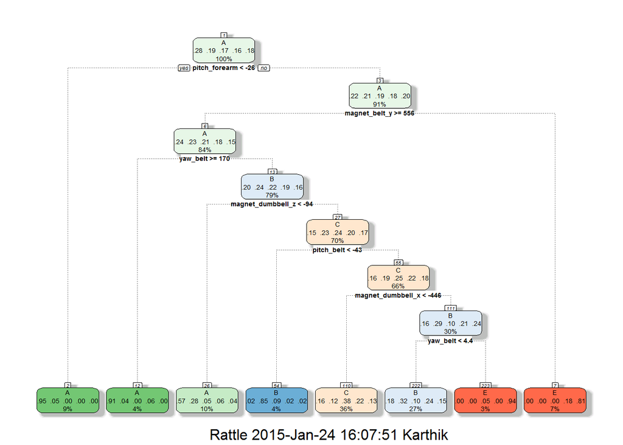

```r
#Plotting tree
library(rattle)
fancyRpartPlot(fit$finalModel)
```

Using Tree package summarizing the confusion matrix

```r
tree.train = tree(classe~.,data=trainTree)
summary(tree.train)
```

```
##
## Classification tree:
## tree(formula = classe ~ ., data = trainTree)
## Variables actually used in tree construction:
##  [1] "pitch_forearm"     "magnet_belt_y"     "accel_forearm_z"
##  [4] "magnet_dumbbell_y" "roll_forearm"      "magnet_dumbbell_z"
##  [7] "pitch_belt"        "yaw_belt"          "accel_dumbbell_y"
## [10] "accel_forearm_x"   "accel_forearm_y"   "magnet_arm_x"
## [13] "accel_dumbbell_z"
## Number of terminal nodes:  24
## Residual mean deviance:  1.546 = 18170 / 11750
## Misclassification error rate: 0.2991 = 3522 / 11776
```

```r
tree.pred=predict(tree.train,testTree,type="class")
predTab = with(testTree,table(tree.pred,classe))
sum(diag(predTab))/sum(as.vector(predTab)) # error rate
```

```
## [1] 0.6969156
```

Pruning Tree

```r
cv.train = cv.tree(tree.train,FUN=prune.misclass)
cv.train
```

```
## $size
##  [1] 24 23 22 21 20 19 17 16 14 13  7  5  1
##
## $dev
##  [1] 3585 3618 3698 4123 4251 4390 4413 4474 4609 4609 5796 6207 8428
##
## $k
##  [1]     -Inf  41.0000  74.0000 109.0000 117.0000 122.0000 123.5000
##  [8] 125.0000 131.0000 134.0000 171.6667 229.0000 546.7500
##
## $method
## [1] "misclass"
##
## attr(,"class")
## [1] "prune"         "tree.sequence"
```

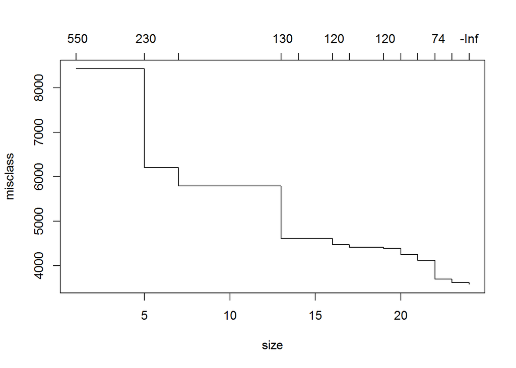

```r
plot(cv.train)
```

```r
prune.train=prune.misclass(tree.train,best=10)
tree.pred=predict(prune.train,testTree,type="class")
predMatrix = with(testTree,table(tree.pred,classe))
sum(diag(predMatrix))/sum(as.vector(predMatrix)) # error rate
```

```
## [1] 0.5927861
```

```r
#Using Random Forest
require(randomForest)
set.seed(123451)
rf.train <- randomForest(classe~.,data=trainTree,nTree=100,importance=TRUE)
rf.train
```

```
##
## Call:
##  randomForest(formula = classe ~ ., data = trainTree, nTree = 100,      importance = TRUE)
##                Type of random forest: classification
##                      Number of trees: 500
## No. of variables tried at each split: 6
##
##         OOB estimate of  error rate: 0.83%
## Confusion matrix:
##      A    B    C    D    E class.error
## A 3341    6    0    0    1 0.002090800
## B   22 2247   10    0    0 0.014041246
## C    0   15 2037    2    0 0.008276534
## D    0    0   29 1897    4 0.017098446
## E    0    0    2    7 2156 0.004157044
```

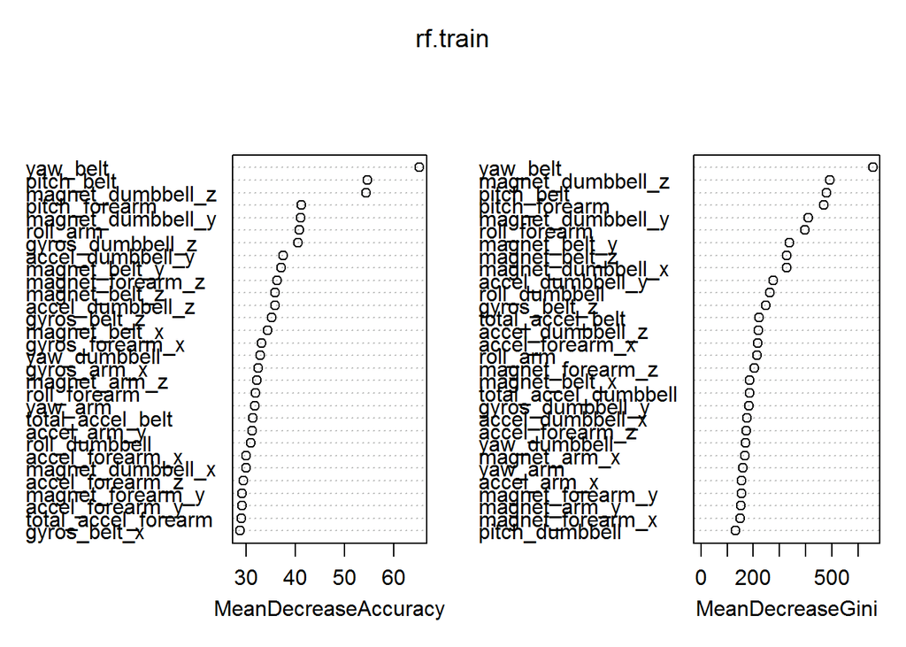

```r
#Plotting Rf
varImpPlot(rf.train)
```

```r
importance(rf.train)
```

```
##                             A        B        C        D        E
## pitch_belt           31.80567 52.93412 41.73505 38.34870 40.29951
## yaw_belt             58.66582 46.96282 42.95179 51.74523 36.62377
## total_accel_belt     22.89860 27.16275 25.45398 24.66810 24.15943
## gyros_belt_x         19.24404 21.43342 21.63778 17.57350 20.07824
## gyros_belt_y         13.42067 18.90653 17.53117 17.33570 20.25793
## gyros_belt_z         23.46355 31.58329 28.28313 27.77558 32.56080
## magnet_belt_x        19.67847 26.25471 27.41773 22.61111 30.86763
## magnet_belt_y        26.80198 32.54813 33.07710 32.86021 29.51002
## magnet_belt_z        28.50016 31.18077 28.69040 32.47572 29.35817
## roll_arm             23.83249 32.85162 32.60819 32.30385 25.93450
## pitch_arm            19.59028 25.28036 22.36713 21.16329 19.54557
## yaw_arm              22.27162 28.13862 26.22967 27.60271 23.15222
## total_accel_arm      12.04556 25.32284 19.08086 19.66206 20.43470
## gyros_arm_x          17.52849 30.27881 24.79307 26.80645 23.13443
## gyros_arm_z          13.33580 16.98727 15.43545 13.32036 16.76917
## accel_arm_x          16.20862 18.67649 19.41915 21.92131 15.84577
## accel_arm_y          19.64593 23.49724 20.66648 21.04940 21.22420
## accel_arm_z          14.77376 22.04973 23.24647 24.82385 22.83527
## magnet_arm_x         18.08633 17.98708 20.73144 19.03568 17.00765
## magnet_arm_y         13.39095 18.36693 18.74667 21.69423 15.21775
## magnet_arm_z         21.33554 28.35729 24.15024 22.81856 21.72559
## roll_dumbbell        24.13352 28.01235 28.17840 29.82328 25.53254
## pitch_dumbbell       12.82659 22.25941 19.14563 15.10108 16.94164
## yaw_dumbbell         18.73577 27.81317 26.72337 24.38432 27.67636
## total_accel_dumbbell 21.60411 25.08005 20.83461 23.17410 26.28517
## gyros_dumbbell_y     22.16030 22.33932 28.81367 22.59192 21.20969
## gyros_dumbbell_z     19.71132 27.27254 21.01417 21.94324 19.92851
## accel_dumbbell_x     18.13501 24.87798 21.91982 20.65672 21.58381
## accel_dumbbell_y     27.75485 30.28668 33.91840 28.64755 30.97260
## accel_dumbbell_z     21.48154 29.90820 25.96909 27.97639 30.19882
## magnet_dumbbell_x    25.43282 27.78215 30.88294 29.28150 24.07837
## magnet_dumbbell_y    32.74917 34.33338 44.29585 35.23791 30.84668
## magnet_dumbbell_z    46.52532 42.55395 51.52841 39.90847 39.84778
## roll_forearm         31.13231 27.53741 35.13845 25.29611 26.02036
## pitch_forearm        30.65960 35.29812 38.11555 34.07930 35.78055
## yaw_forearm          17.44340 22.18461 22.10302 21.32889 21.64589
## total_accel_forearm  21.00860 22.02657 21.88023 17.89641 19.48722
## gyros_forearm_x      14.87268 17.84289 22.00962 19.39891 19.62628
## gyros_forearm_y      13.80207 28.63658 23.29189 24.87999 22.86079
```

[output cut: 37 more lines]

```
## magnet_dumbbell_x                29.90202        326.42542
## magnet_dumbbell_y                41.01313        410.20727
## magnet_dumbbell_z                54.44166        491.85315
## roll_forearm                     31.85071        396.89561
## pitch_forearm                    41.23815        469.02968
## yaw_forearm                      27.18561        117.95015
## total_accel_forearm              28.94189         82.51258
## gyros_forearm_x                  33.17627         62.08797
## gyros_forearm_y                  28.12917         97.19265
## accel_forearm_x                  30.01102        217.81480
## accel_forearm_y                  29.09921         99.10301
## accel_forearm_z                  29.47241        173.42621
## magnet_forearm_x                 23.81624        149.10503
## magnet_forearm_y                 29.14987        154.04713
## magnet_forearm_z                 36.22781        203.61854
```

```r
#Predicting RandomForest Accuracy
rf.pred=predict(rf.train,testTree,type="class")
predRFTab = with(testTree,table(rf.pred,classe))
sum(diag(predRFTab))/sum(as.vector(predRFTab)) # error rate
```

```
## [1] 0.9924802
```

```r
#Conclusion
prediction <- predict(rf.train, dataTest)
prediction
```

```
##  1  2  3  4  5  6  7  8  9 10 11 12 13 14 15 16 17 18 19 20
##  B  A  B  A  A  E  D  B  A  A  B  C  B  A  E  E  A  B  B  B
## Levels: A B C D E
```

To Generate 20 different files of test set prediction

```r
pml_write_files = function(x){
  n = length(x)
  for(i in 1:n){
    filename = paste0("problem_id_",i,".txt")
    write.table(x[i],file=filename,quote=FALSE,row.names=FALSE,col.names=FALSE)
  }
}

pml_write_files(prediction)
```